# Lab 3 Scoring 2

Wajd

25 mars 2018

## Classification

### Libraries

```r
library(caret) #sampling
library(dummies) #dummify categorical variables
library(DMwR) #smote the world
library(randomForest) #speaks for itself
library(knitr) #knit things
library(ROCR)  #roc n roll
```

```r
library(plotly) #never used this. Sad
```

### Custom Functions

Gets you the proportions and the table

```r
pct <- function(x){
  tbl <- table(x)
  tbl_pct <- cbind(tbl,round(prop.table(tbl)*100,2))
  colnames(tbl_pct) <- c('Count','Percentage')
  kable(tbl_pct)
}
```

Gets you the mode of a categorical variable

```r
Mode <- function(x) {
  ux <- unique(x)
  ux[which.max(tabulate(match(x, ux)))]
}
```

Used for testing. Change the cutoff of random forest after random forest

```r
threshold_1 <- function(p,t) {
  if (p > t) 1 else 0
}
```

### Data collection

We will recover the database from a file, AssuranceExpertsInc.txt, containing informations about clients grouped by postal code.

```r
DirtyInsurance <- read.table("AssurancExpertsInc.txt", header=T,fill=T, encoding="utf-8", sep="\t", dec=".",quote = "", na.string=" " )
columnNames<- read.table("columns.txt", header=F,fill=T, encoding="utf-8", sep="\n", dec=".",quote = "", na.string=" " )
colnames(DirtyInsurance)<-as.vector(columnNames$V1)
```

### Data Description

The columns are divided between sociodemographic columns, and columns related to insurance. Besides, the column names are not significant. Thus we have recovered the true column names from the descriptive file and we will assign each name to its respective column.

### Data Preparation

We have noticed that the modalities of each column range from 0 to 40, with each modality representing a certain real world modality. Our values are not ordinal, thus we will have to correctly identify every modality with its respective real world modality, and we will have to dummify our dataset.

First, we recover the customer subtype, and we will assign the modalities to the respective columns. Then we recover the customer main type and we do the same thing.

```r
L0<- read.table("L0.txt", header=F,fill=T, encoding="utf-8", sep="\n", dec=".",quote = "", na.string=" " )
CustomerSubtypeDummies=dummy(DirtyInsurance$CustomerSubtype, sep = "_")
colnames(CustomerSubtypeDummies)<-as.vector(L0$V1)
#Problem: Modality 14 missing. Checking: Junior cosmopolitans. Deleted from columns dataset.

L2<- read.table("L2.txt", header=F,fill=T, encoding="utf-8", sep="\n", dec=".",quote = "", na.string=" " )
CustomerMainType=dummy(DirtyInsurance$CustomerMainType, sep = "_")
colnames(CustomerMainType)<-as.vector(L2$V1)
```

Now, we will have to get rid of two columns. STATUS says if the column is a part of the training set or the testing set. CLASS is our target value. We will have to skip both of these before we dummify the rest of the dataset.

```r
isTrain=DirtyInsurance$STATUS
target=DirtyInsurance$CLASS
targetFactor=DirtyInsurance$CLASS
target=as.numeric(target)
CleanerInsurance<-DirtyInsurance[,!(colnames(DirtyInsurance)%in% c("CLASS","STATUS" ))]
colnames(CleanerInsurance)
```

```
##  [1] "CustomerSubtype"
##  [2] "Numberofhouses "
##  [3] "sizehousehold 1 – 6"
##  [4] "Avgage"
##  [5] "CustomerMainType"
##  [6] "Catholic"
##  [7] "Protestant"
##  [8] "Otherreligion"
##  [9] "Noreligion"
## [10] "Married"
## [11] "Living together"
## [12] "Other relation"
## [13] "Singles"
## [14] "Household without children"
## [15] "Household with children"
```

[output cut: 70 more lines]

Now we integrate our dataset in one.

```r
for(b in colnames(CleanerInsurance[, -c(1, 5)])) CleanerInsurance[[b]] <- as.factor(CleanerInsurance[[b]])

Dummified=dummy.data.frame(CleanerInsurance[, -c(1, 5)], sep = "_")

AllDummies=cbind(CustomerMainType,CustomerSubtypeDummies,CleanerInsurance[, -c(1, 5)])
```

```r
for(b in colnames(AllDummies)) AllDummies[[b]] <- as.numeric(AllDummies[[b]])

AllDummies$RatioPrivateThirdParty=AllDummies[,92]/AllDummies[,113]
AllDummies$RatioPrivateThirdPartyFirms=AllDummies[,93]/AllDummies[,114]
AllDummies$RatioPrivateThirdPartyAgriculture=AllDummies[,94]/AllDummies[,115]
AllDummies$RatioCar=AllDummies[,95]/AllDummies[,116]
AllDummies$RatioDeliveryVan=AllDummies[,96]/AllDummies[,117]
AllDummies$RatioScooter=AllDummies[,97]/AllDummies[,118]
AllDummies$RatioLorry=AllDummies[,98]/AllDummies[,119]
AllDummies$RatioTrailer=AllDummies[,99]/AllDummies[,120]
AllDummies$RatioTractor=AllDummies[,100]/AllDummies[,121]
AllDummies$RatioMachines=AllDummies[,101]/AllDummies[,122]
AllDummies$RatioMoped=AllDummies[,102]/AllDummies[,123]
AllDummies$RatioLife=AllDummies[,103]/AllDummies[,124]
AllDummies$RatioPrivateAccidents=AllDummies[,104]/AllDummies[,125]
AllDummies$RatioFamily=AllDummies[,105]/AllDummies[,126]
AllDummies$RatioDisability=AllDummies[,106]/AllDummies[,127]
AllDummies$RatioFire=AllDummies[,107]/AllDummies[,128]
AllDummies$RatioSurf=AllDummies[,108]/AllDummies[,129]
AllDummies$RatioBoat=AllDummies[,109]/AllDummies[,130]
AllDummies$RatioBicycle=AllDummies[,110]/AllDummies[,131]
AllDummies$RatioProperty=AllDummies[,111]/AllDummies[,132]
AllDummies$RatioSocialSecurity=AllDummies[,112]/AllDummies[,133]

AllDummies_Ratio=AllDummies[,-c(92:133)]

AllDummies=AllDummies_Ratio
```

Now it’s time to prepare our dataset for the final showdown.

```r
isTrain<-as.numeric(isTrain)
isTrain<-isTrain-1
isTrain<-as.logical(isTrain)

Dummified_3_target=AllDummies
Dummified_3_target=data.frame(AllDummies, target)
Dummified_3_target$target<-as.numeric(Dummified_3_target$target)
Dummified_3_target$target=Dummified_3_target$target-1
Dummified_3_target$target<-as.factor(Dummified_3_target$target)

#div_part_1 <- which(isTrain )
```

We did consider doing crossvalidation or other more sophisticated sampling methods. However training the model on a potato pc is never a good thing. We are forced to do the best we can: stratified sampling. It ensures we always have the right proportions. That’s something!

```r
div_part_1 <- createDataPartition(y = Dummified_3_target$target, p = 0.7, list = F)
train_1 <- Dummified_3_target[div_part_1,] # 70% here
table(train_1$target)
```

```
##
##    0    1
## 6466  411
```

```r
pct(train_1$target)
```

|  | Count | Percentage |
| --- | --- | --- |
| 0 | 6466 | 94.02 |
| 1 | 411 | 5.98 |

```r
test_1 <- Dummified_3_target[-div_part_1,] # rest of the 30% data goes here
pct(test_1$target)
```

|  | Count | Percentage |
| --- | --- | --- |
| 0 | 2770 | 94.06 |
| 1 | 175 | 5.94 |

```r
table(test_1$target)
```

```
##
##    0    1
## 2770  175
```

```r
train_1$target <- as.factor(train_1$target)
train_1_not_smoted=train_1
```

We’ll use the SMOTE to undersample the overrepresented modality and oversample the underrepresented modality. We did our best to tune the algorithm over hours, but the results were not particularly golden.

```r
set.seed(1234)

train_1_smote_1 <- SMOTE(target ~ ., train_1,k=81, perc.over = 150, perc.under=210)
m3 <- randomForest(target ~ .,nodesize=5,mtry=15,ntree=2000, data = train_1_smote_1)
m3_fitForest <- predict(m3, newdata = test_1, type="prob")[,2]
p=sapply(m3_fitForest, threshold_1, t=0.45)
table(p, test_1$target)
```

```
##
## p      0    1
##   0 2171   89
##   1  599   86
```

In order to be able to further tune our model with more data and more trees, we decided to check the gini importance of variables then only take the most important variables.

```r
Imp=m3$importance
library(data.table)
Imp=as.data.frame(Imp)
setDT(Imp, keep.rownames = TRUE)[]
```

```
##                        rn MeanDecreaseGini
##   1: Successful.hedonists       2.93581152
##   2:       Driven.Growers      14.31554773
##   3:       Average.Family       5.59216505
##   4:        Career.Loners       0.05591302
##   5:          Living.well       1.78373510
##  ---
## 108:            RatioSurf       0.22590626
## 109:            RatioBoat       2.92047141
## 110:         RatioBicycle       0.68162752
## 111:        RatioProperty       0.42867827
## 112:  RatioSocialSecurity       1.71315851
```

```r
Imp_1=Imp[Imp$MeanDecreaseGini>=1,]

Dummified_3_target_2=Dummified_3_target[,colnames(Dummified_3_target) %in% c(Imp_1$rn, "target")]
```

We perform a new smote

```r
#Dummified_3_target_2=data.frame(Dummified_3_target_2, target)
Dummified_3_target_2$target<-as.numeric(Dummified_3_target_2$target)
Dummified_3_target_2$target=Dummified_3_target_2$target-1
Dummified_3_target_2$target<-as.factor(Dummified_3_target_2$target)

train_2 <- Dummified_3_target_2[div_part_1,] # 70% here
pct(train_2$target)
```

|  | Count | Percentage |
| --- | --- | --- |
| 0 | 6466 | 94.02 |
| 1 | 411 | 5.98 |

```r
test_2 <- Dummified_3_target_2[-div_part_1,] # rest of the 30% data goes here
pct(test_2$target)
```

|  | Count | Percentage |
| --- | --- | --- |
| 0 | 2770 | 94.06 |
| 1 | 175 | 5.94 |

```r
train_2$target <- as.factor(train_2$target)

train_2_smote_1 <- SMOTE(target ~ ., train_2,k=5, perc.over = 500, perc.under=50)
table(train_2_smote_1$target)
```

```
##
##    0    1
## 1027 2466
```

now the model you see in comments is huge. It took a long time to train and the potato ram we have couldn’t handle any more data. We saved it in a RData file to continue.

```r
#m3_1 <- randomForest(target ~ .,nodesize=1,mtry=10,ntree=20000, data = train_2_smote_1)

#save(m3_1, file = "m3_1.RData")
#save(test_2, file = "test_2.RData")
#save(train_2, file = "train_2.RData")
#save(Dummified_3_target_2, file = "Dummified_3_target_2.RData")

load("m3_1.RData")
load("test_2.RData")
load("train_2.RData")
load("Dummified_3_target_2.RData")
```

Let’s check how good it is with the testing set

```r
m3_1_fitForest <- predict(m3_1, newdata = test_2, type="prob")[,2]
table(round(m3_1_fitForest), test_2$target)
```

```
##
##        0    1
##   0 2191   92
##   1  579   83
```

Well, we did catch half the target, which is not half bad.

```r
m3_1_fitForest_train <- predict(m3_1, newdata = train_2, type="prob")[,2]
table(round(m3_1_fitForest_train), train_2$target)
```

```
##
##        0    1
##   0 5326   17
##   1 1140  394
```

```r
m3_1_pred <- prediction( m3_1_fitForest, test_2$target)
m3_1_perf <- performance(m3_1_pred, "tpr", "fpr")
```

Now, let’s go check out the roc curve

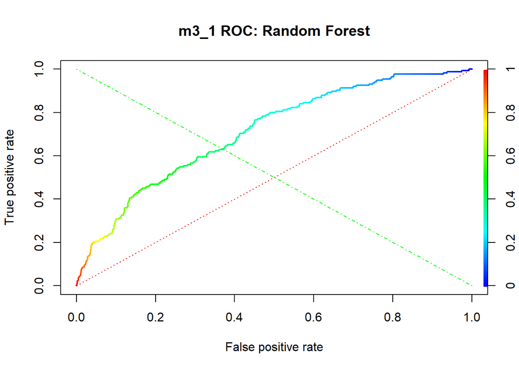

```r
plot(m3_1_perf,colorize=TRUE, lwd=2, main = "m3_1 ROC: Random Forest", col = "blue")
lines(x=c(0, 1), y=c(0, 1), col="red", lwd=1, lty=3);
lines(x=c(1, 0), y=c(0, 1), col="green", lwd=1, lty=4)
```

It’s pretty good. Not perfect. Far from perfect. But it can suit our needs

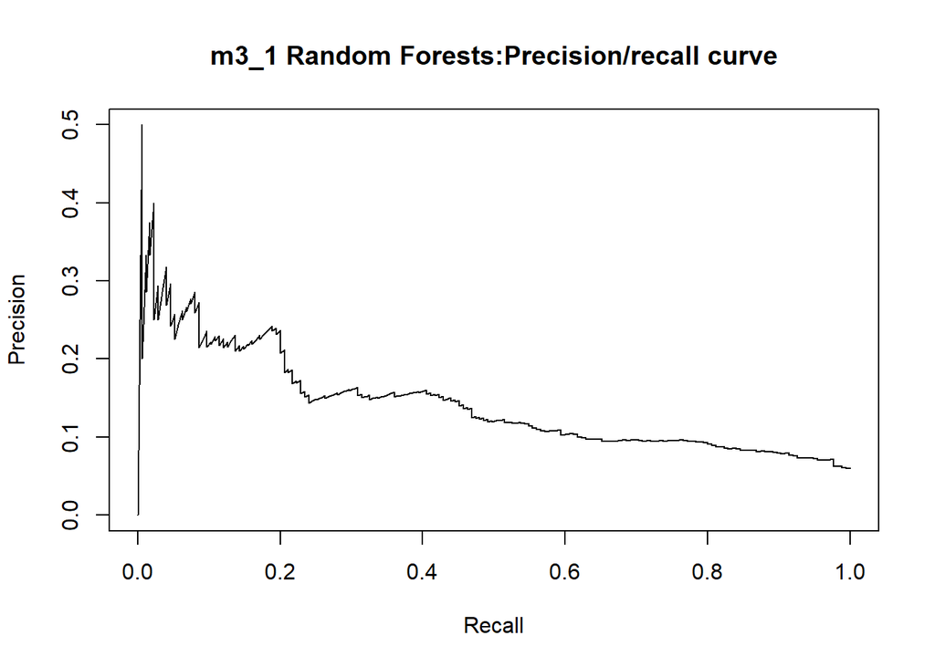

```r
# Plot precision/recall curve
m3_1_perf_precision <- performance(m3_1_pred, measure = "prec", x.measure = "rec")
plot(m3_1_perf_precision, main="m3_1 Random Forests:Precision/recall curve")
```

Same for the precision, recall curve.

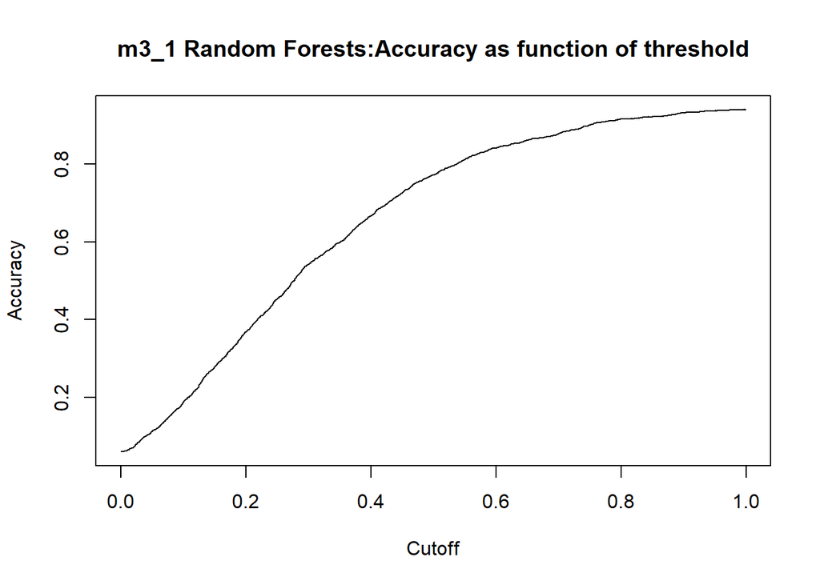

```r
m3_1_perf_acc <- performance(m3_1_pred, measure = "acc")
plot(m3_1_perf_acc, main="m3_1 Random Forests:Accuracy as function of threshold")
```

The accuracy as a function of threshold cannot exactly be used due the fact that we are seeking the true positives rate and not the accuracy itself.

```r
#KS & AUC  m3_1
m3_1_AUROC <- round(performance(m3_1_pred, measure = "auc")@y.values[[1]]*100, 2)
m3_1_KS <- round(max(attr(m3_1_perf,'y.values')[[1]] - attr(m3_1_perf,'x.values')[[1]])*100, 2)
m3_1_Gini <- (2*m3_1_AUROC - 100)
cat("AUROC: ",m3_1_AUROC,"\tKS: ", m3_1_KS, "\tGini:", m3_1_Gini, "\n")
```

```
## AUROC:  71   KS:  31.55  Gini: 42
```

Now, we move on to the scoring. For that, we’ll need the full dataset.

```r
m3_1_fitForest_all <- predict(m3_1, newdata = Dummified_3_target_2, type="prob")[,2]
table(round(m3_1_fitForest_all), Dummified_3_target_2$target)
```

```
##
##        0    1
##   0 7517  109
##   1 1719  477
```

# SCORING

We will select the 12 areas with the highest probability according to our model to want a caravan, and the 12 areas with the smallest probability according to our model to want a caravan. We expect them to be correctly separated, allowing us to extract the most influent variables and their effects

```r
Dummies_proba_all<-data.frame(Dummified_3_target_2, m3_1_fitForest_all)

selected_yes=head(Dummies_proba_all[order(Dummies_proba_all$m3_1_fitForest_all, decreasing = T),],12)
selected_no=head(Dummies_proba_all[order(Dummies_proba_all$m3_1_fitForest_all, decreasing = F),],12)

selected=rbind(selected_no, selected_yes)
```

We start first by analysing their averages.

```r
for(b in colnames(selected)) selected[[b]] <- as.numeric(selected[[b]])
selected_mean=aggregate(selected,by=list(selected$target),FUN=mean)
head(selected_mean)
```

```
##   Group.1 Successful.hedonists Driven.Growers Average.Family Living.well
## 1       1                    0      0.1333333     0.06666667           0
## 2       2                    0      0.4444444     0.55555556           0
##   Retired.and.Religeous Family.with.grown.ups Conservative.families
## 1                     0             0.4666667             0.3333333
## 2                     0             0.0000000             0.0000000
##   Farmers High.Income..expensive.child High.status.seniors
## 1       0                            0                   0
## 2       0                            0                   0
##   Middle.class.families Modern..complete.families Stable.family
## 1             0.1333333                         0             0
## 2             0.4444444                         0             0
##   Family.starters Affluent.young.families Young.all.american.family
## 1               0               0.0000000                0.06666667
## 2               0               0.2222222                0.33333333
##   Mixed.seniors.1 Lower.class.large.families Village.families
## 1               0                 0.06666667                0
## 2               0                 0.00000000                0
##   Couples.with.teens..Married.with.children. Mixed.small.town.dwellers
## 1                                          0                         0
## 2                                          0                         0
##   Traditional.families Large.religous.families Numberofhouses.
## 1            0.3333333                       0        1.133333
## 2            0.0000000                       0        1.555556
##   sizehousehold.1...6   Avgage Catholic Protestant Otherreligion
## 1            3.133333 3.000000 1.066667   7.133333      1.133333
## 2            3.555556 2.777778 1.888889   5.666667      2.111111
##   Noreligion  Married Living.together Other.relation  Singles
## 1   3.866667 7.333333        1.066667       3.666667 2.000000
## 2   4.222222 9.000000        1.333333       2.000000 1.555556
##   Household.without.children Household.with.children High.level.education
## 1                   3.933333                6.133333             1.066667
## 2                   2.444444                8.222222             2.222222
##   Medium.level.education Lower.level.education High.status Entrepreneur
## 1               3.533333              7.533333    1.200000            1
## 2               6.222222              4.111111    2.777778            1
##     Farmer Middle.management Skilled.labourers Unskilled.labourers
## 1 1.933333          2.600000          4.133333            4.733333
## 2 1.000000          8.111111          1.666667            1.444444
##   Social.class.A Social.class.B1 Social.class.B2 Social.class.C
```

[output cut: 8 more lines]

```
##   Income.30.45.000 Income.45.75.000 Income.75.122.000 Income..123.000
## 1         5.133333         2.200000          1.066667               1
## 2         6.111111         3.666667          2.555556               1
##   Average.income Purchasing.power.class RatioPrivateThirdParty
## 1       3.266667               4.933333                    1.1
## 2       5.666667               6.666667                    1.5
##   RatioPrivateThirdPartyAgriculture RatioCar RatioScooter RatioMoped
## 1                                 1      1.2            1        1.2
## 2                                 1      2.0            1        1.0
##   RatioLife RatioFire RatioBoat RatioBicycle RatioSocialSecurity target
## 1         1       1.3         1            1            1.000000      1
## 2         1       2.5         1            1            1.222222      2
##   m3_1_fitForest_all
## 1          0.2011767
## 2          0.9999278
```

We noticed that there are variables with similar averages. Thus these variables are not separating our individuals correctly and we should get rid of them.

```r
Uselessvector <- c()
for(b in colnames(selected_mean)) if (selected_mean[[b]][1]==selected_mean[[b]][2]) {Uselessvector<-c(Uselessvector, b)}
head(Uselessvector)
```

```
## [1] "Successful.hedonists"         "Living.well"
## [3] "Retired.and.Religeous"        "Farmers"
## [5] "High.Income..expensive.child" "High.status.seniors"
```

UselessVector contains the names of the variables we are going to get rid of. Let’s do it!

```r
selected_mean<-selected_mean[,!(colnames(selected_mean) %in% Uselessvector)]
selected <- selected[,!(colnames(selected) %in% Uselessvector)]
selected$target<-selected$target-1
```

Now, we will take a look at qualitative variables and get rid of variables with the same Mode.

```r
selected_quali<-selected[, (colnames(selected) %in%  colnames(selected[1:10]))]
selected_quanti<-selected[, (colnames(selected) %in%  colnames(selected[11:(length(colnames(selected))-2)]))]

for(b in colnames(selected_quali)) selected_quali[[b]]<-as.factor(selected_quali[[b]])
for(b in colnames(selected_quanti)) selected_quanti[[b]] <- as.numeric(selected_quanti[[b]])

selected_means_quanti=aggregate(selected_quanti,by=list(selected$target),FUN=mean)
selected_mode_quali=aggregate(selected_quali,by=list(selected$target),FUN=Mode)


UselessvectorQuali <- c()
for(b in colnames(selected_mode_quali)) if (selected_mode_quali[[b]][1]==selected_mode_quali[[b]][2]) {UselessvectorQuali<-c(UselessvectorQuali, b)}
head(UselessvectorQuali)
```

```
## [1] "Driven.Growers"            "Family.with.grown.ups"
## [3] "Conservative.families"     "Middle.class.families"
## [5] "Affluent.young.families"   "Young.all.american.family"
```

```r
selected <- selected[,!(colnames(selected) %in% UselessvectorQuali)]
selected_mode_quali<-selected_mode_quali[,!(colnames(selected_mode_quali) %in% UselessvectorQuali)]
dim(selected_mode_quali)
```

```
## [1] 2 3
```

```r
dim(selected_means_quanti)
```

```
## [1]  2 44
```

```r
selected_means_quanti
```

```
##   Group.1 sizehousehold.1...6   Avgage Catholic Protestant Otherreligion
## 1       0            3.133333 3.000000 1.066667   7.133333      1.133333
## 2       1            3.555556 2.777778 1.888889   5.666667      2.111111
##   Noreligion  Married Living.together Other.relation  Singles
## 1   3.866667 7.333333        1.066667       3.666667 2.000000
## 2   4.222222 9.000000        1.333333       2.000000 1.555556
##   Household.without.children Household.with.children High.level.education
## 1                   3.933333                6.133333             1.066667
## 2                   2.444444                8.222222             2.222222
##   Medium.level.education Lower.level.education High.status   Farmer
## 1               3.533333              7.533333    1.200000 1.933333
## 2               6.222222              4.111111    2.777778 1.000000
##   Middle.management Skilled.labourers Unskilled.labourers Social.class.A
## 1          2.600000          4.133333            4.733333            1.6
## 2          8.111111          1.666667            1.444444            2.0
##   Social.class.B1 Social.class.B2 Social.class.C Social.class.D
## 1        1.666667        1.333333       7.066667       2.933333
## 2        3.888889        3.888889       4.222222       1.000000
##   Rented.house Home.owners   X1.car  X2.cars   No.car
## 1     5.000000    6.000000 5.333333 3.466667 3.933333
## 2     3.777778    7.222222 8.000000 3.000000 1.555556
##   National.Health.Service Private.health.insurance Income...30.000
## 1                7.933333                 3.066667        5.200000
## 2                6.222222                 4.777778        1.444444
##   Income.30.45.000 Income.45.75.000 Income.75.122.000 Average.income
## 1         5.133333         2.200000          1.066667       3.266667
## 2         6.111111         3.666667          2.555556       5.666667
##   Purchasing.power.class RatioPrivateThirdParty RatioCar RatioMoped
## 1               4.933333                    1.1      1.2        1.2
## 2               6.666667                    1.5      2.0        1.0
##   RatioFire RatioSocialSecurity
## 1       1.3            1.000000
## 2       2.5            1.222222
```

Most values here represent proportions. For instance, a value of 10 represents a proportion of 90-100%, a value of 5 represents a value of 40-50%.

The plan here is to assign a sign to each key variable in order to be able to assign a score based on this sign, the variable’s value and its gini score.

## AGE

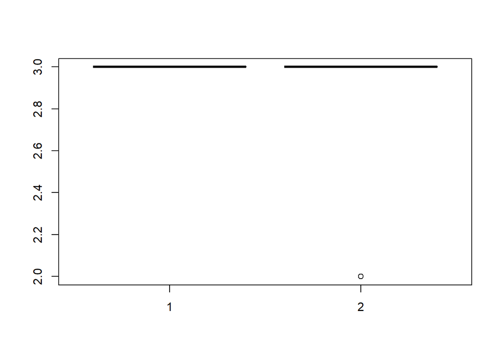

```r
boxplot(selected_no$Avgage, selected_yes$Avgage)
```

Ages are of little meaning. We do note that the areas of those who said yes are slightly younger on average.

[Sign: None]

## RELIGION

### Catholic

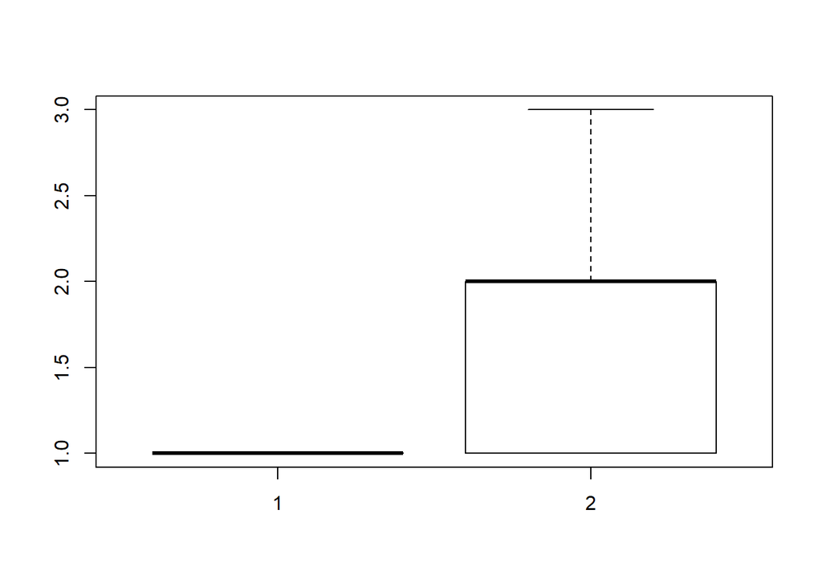

```r
boxplot(selected_no$Catholic, selected_yes$Catholic)
```

Areas with a higher proportion of catholics said yes more often than not.

[Sign: Positive]

### PROTESTANT

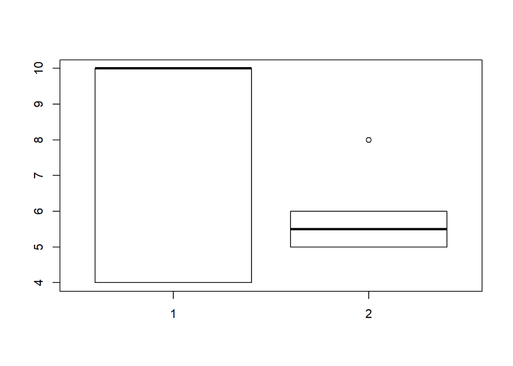

```r
boxplot(selected_no$Protestant, selected_yes$Protestant)
```

Areas with a higher proportion of protestant christians say no more often than yes

[Sign: Negative]

### RELIGION CONCLUSION

Catholics are renowned for their stronger attachment to family and family values than protestants. Since using a caravan is a family activity, it makes sense to see them more willing to buy it than not.

## MARITAL STATUS

### MARRIED

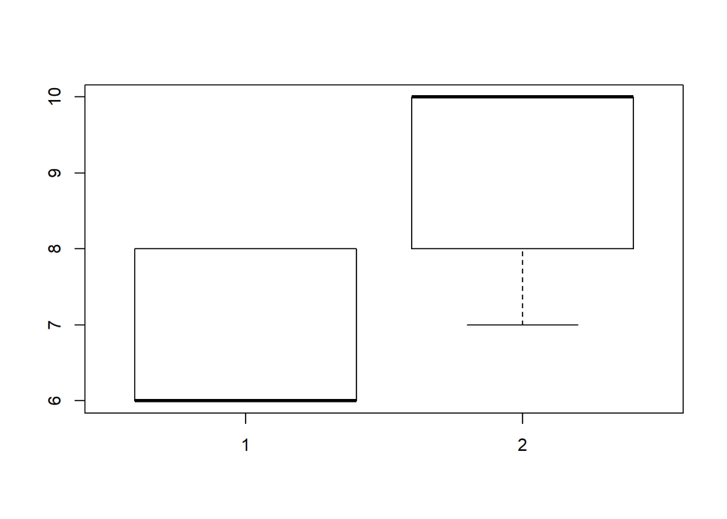

```r
boxplot(selected_no$Married, selected_yes$Married)
```

Areas with a higher proportion of married people say yes more often than not.

[Sign: Positive]

### OTHER RELATION

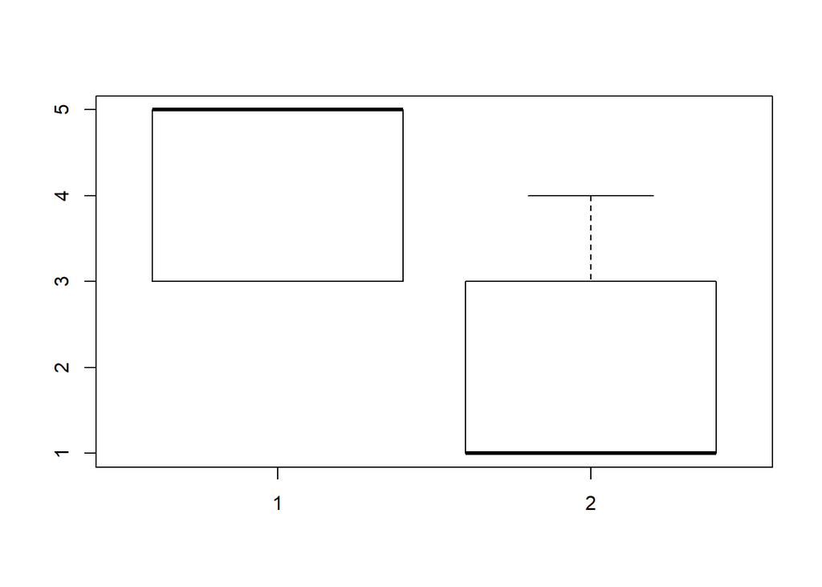

```r
boxplot(selected_no$Other.relation, selected_yes$Other.relation)
```

[Sign: Negative]

### SINGLE

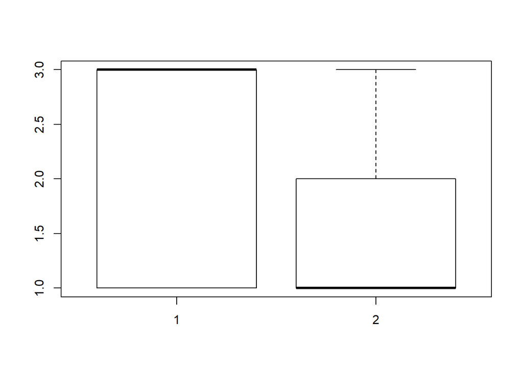

```r
boxplot(selected_no$Singles, selected_yes$Singles)
```

Same for single people. The more singles in an area, the higher the chance of them not wanting a caravan.

[Sign: Negative]

### Marital Status Conclusion:

Family stability makes you say yes more often than not

## CHILDREN

### NO CHILDREN

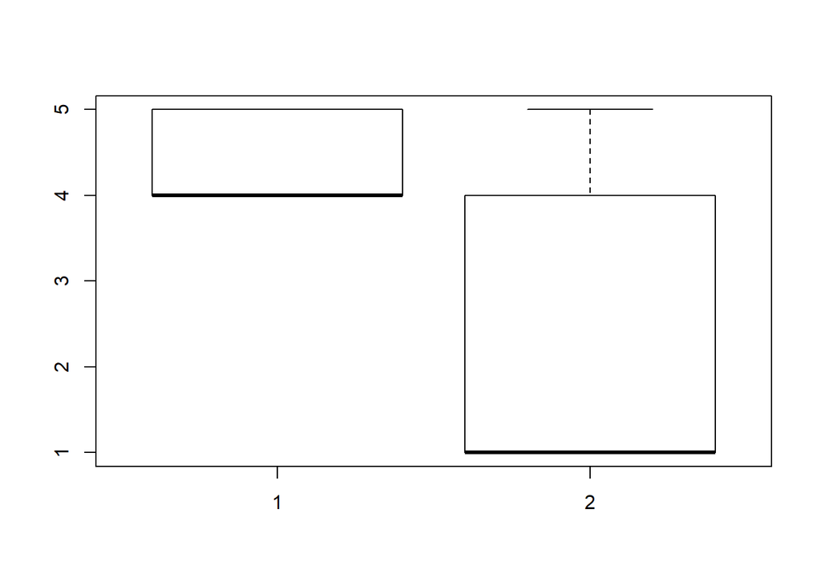

```r
boxplot(selected_no$Household.without.children, selected_yes$Household.without.children)
```

Areas with a higher proportion of families without children say no more often than yes.

[Sign: Negative]

### HOUSEHOLD WITH CHILDREN

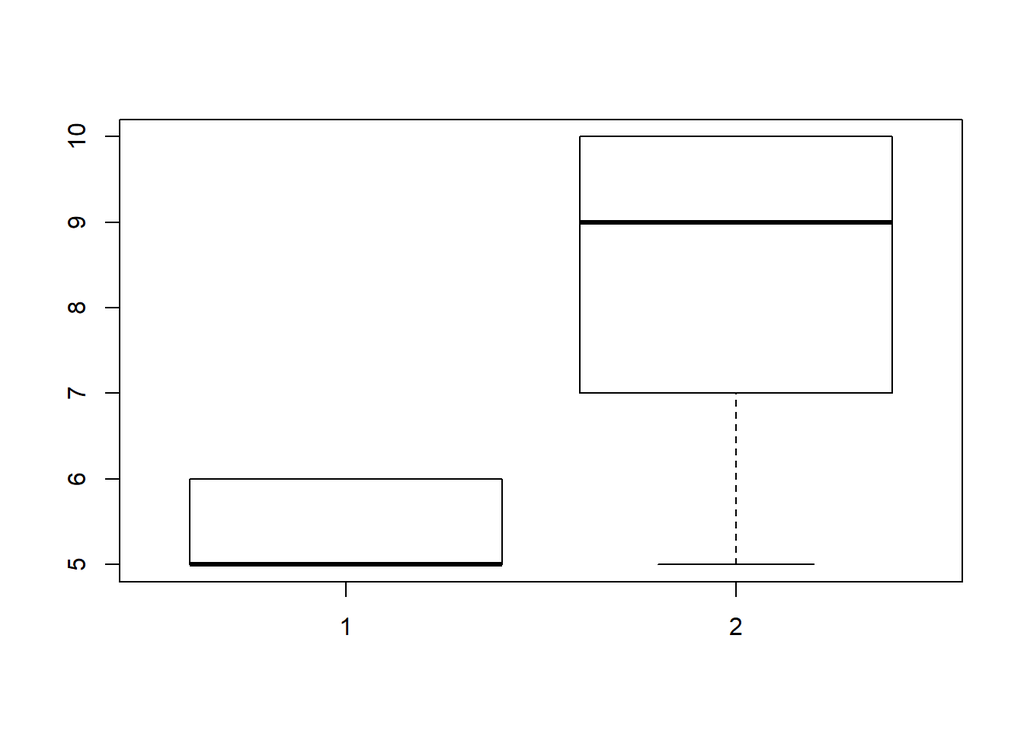

```r
boxplot(selected_no$Household.with.children, selected_yes$Household.with.children)
```

Areas with a higher proportion of families with children say yes more often than no.

[Sign: Positive]

### Conclusion about family and children

This confirms the initial statement. If you have a stable relationship and if you have children, then you have a higher chance of saying yes.

## EDUCATION

### HIGH LEVEL EDUCATION

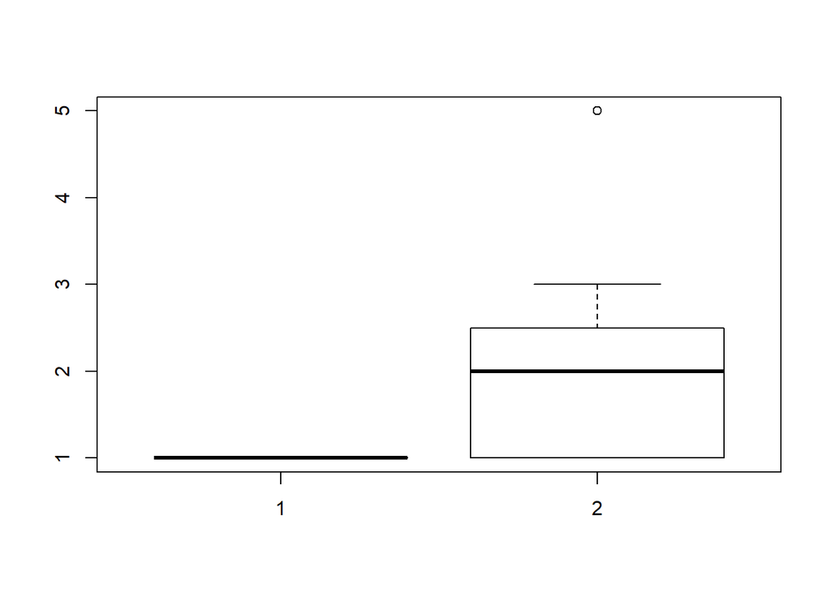

```r
boxplot(selected_no$High.level.education, selected_yes$High.level.education)
```

Areas with a high proportion of people with a high education say yes more often than not. But what about medium and lower education?

[Sign: Positive]

### MEDIUM LEVEL EDUCATION

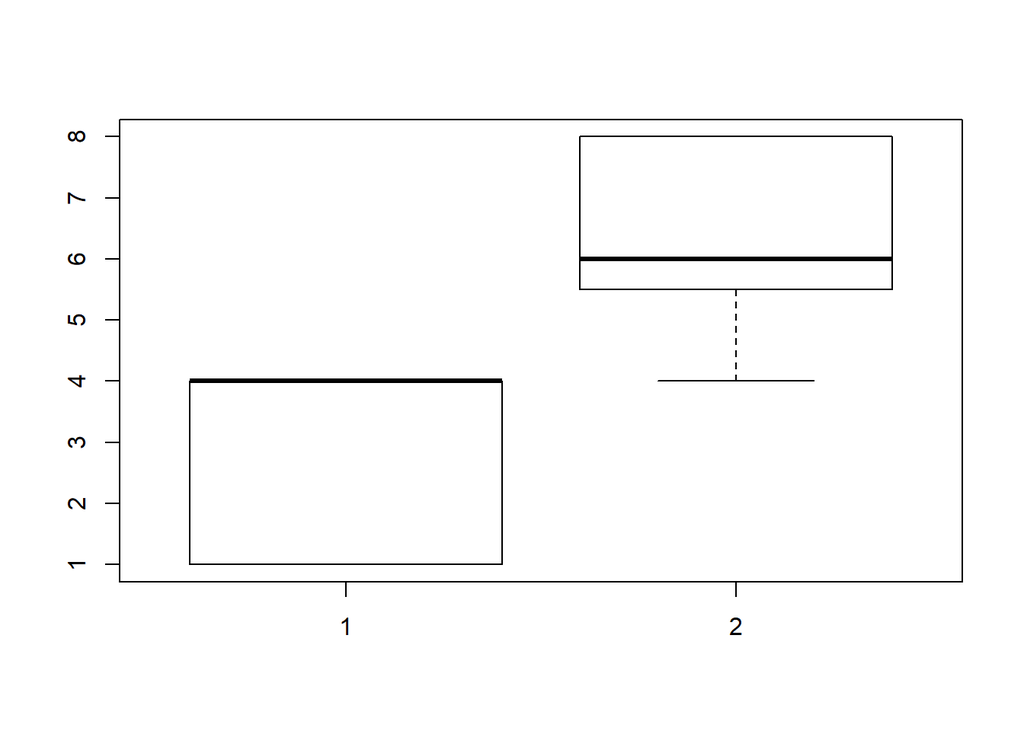

```r
boxplot(selected_no$Medium.level.education , selected_yes$Medium.level.education )
```

Areas with a high proportion of people with medium education say yes more often than not, however, it is less so than people with a higher education.

[Sign: Positive]

### LOWER LEVEL EDUCATION

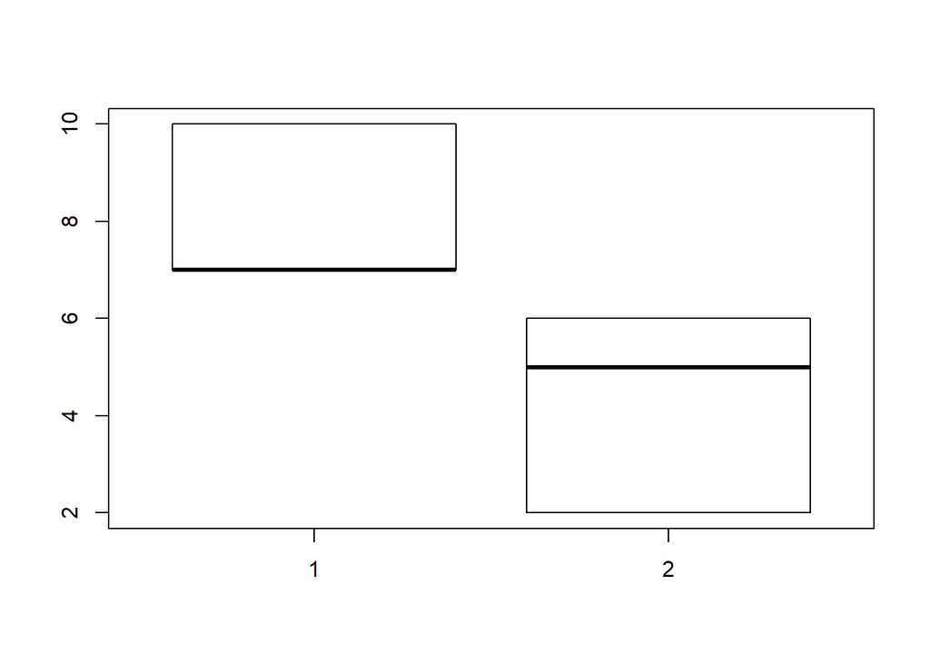

```r
boxplot(selected_no$Lower.level.education , selected_yes$Lower.level.education )
```

Areas with a high proportion of people with low education say no more often than yes.

[Sign: Negative]

### Conclusion education:

There’s a positive correlation with the proportion of highly educated customers in an area and their intention of purchasing a caravan.

## SOCIAL STATUS/OCCUPATION

### HIGH STATUS

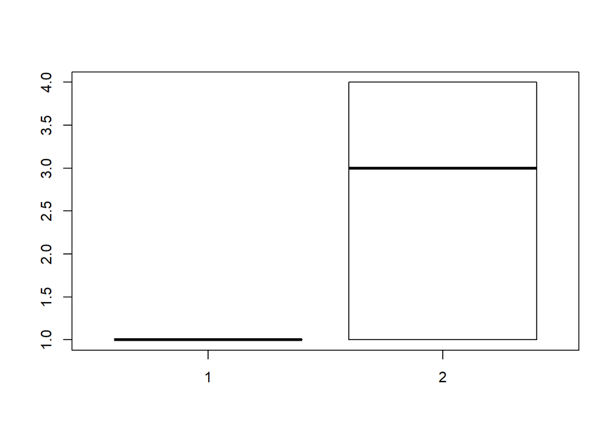

```r
boxplot(selected_no$High.status , selected_yes$High.status )
```

Areas with a high proportion of people with higher social status say yes more often than not. We wonder how is it for other occupations.

[Sign: Positive]

### FARMER

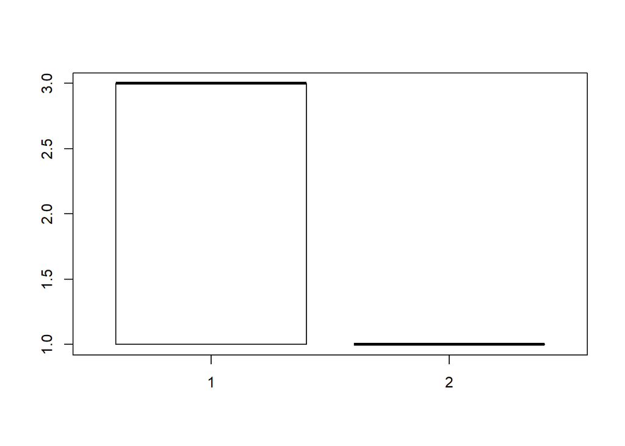

```r
boxplot(selected_no$Farmer , selected_yes$Farmer )
```

Areas with a higher proportion of farmers say no more often than yes. It’s understandable: These areas are often rural in nature, and farmers are with nature all day long. Why would they need a caravan? To go to more nature?

[Sign: Negative]

### MIDDLE MANAGEMENT

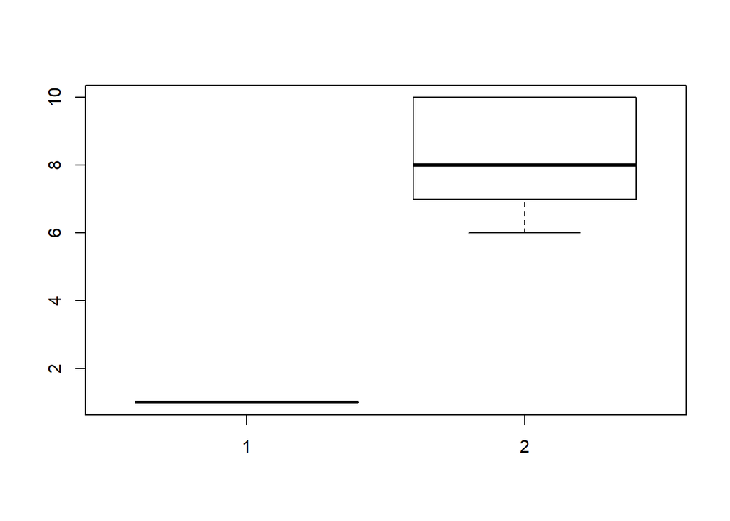

```r
boxplot(selected_no$Middle.management , selected_yes$Middle.management )
```

Areas with a higher proportion of people working in middle management say yes more often than not. The middle manager is an employee in an organization managing a level between senior and junior managers, thus it’s often a job for highly educated upper middle class.

[Sign: Positive]

### SKILLED LABOURERS

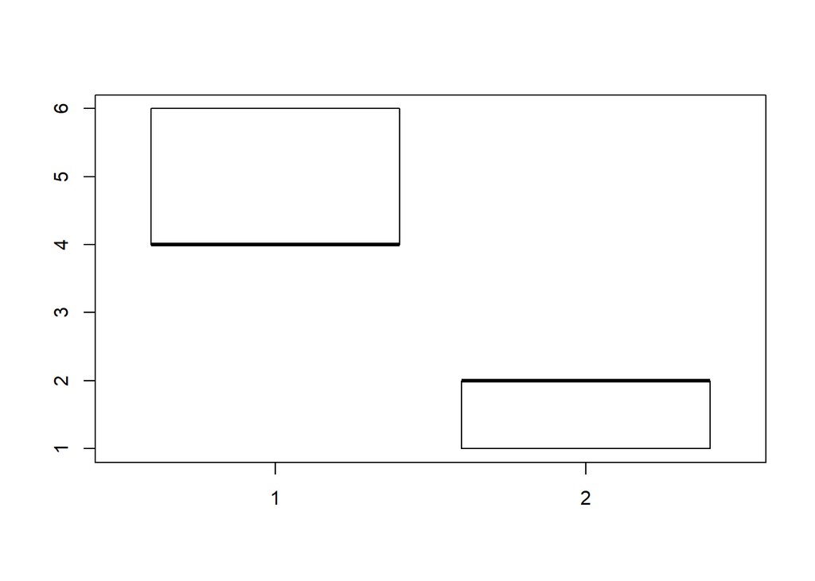

```r
boxplot(selected_no$Skilled.labourers , selected_yes$Skilled.labourers )
```

Areas with a higher proportion of Skilled labourers say no more often than yes. It is understandable: Skilled labourers are actually blue collar workers, doing low grade work that does require certain skills, like electrician or carpenter.

[Sign: Negative]

### UNSKILLED LABOURERS

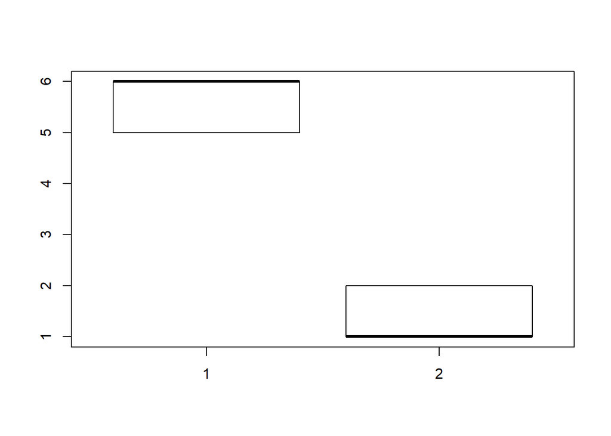

```r
boxplot(selected_no$Unskilled.labourers , selected_yes$Unskilled.labourers )
```

Areas with a higher proportion of unskilled labourers say no more often than yes. Unskilled labourers are people with little to no education, doing mainly manual work for a low pay. Still, skilled workers say yes more often than unskilled workers (notice the higher median)

[Sign: Negative]

### OCCUPATION CONCLUSION

There seems to be a positive correlation between the social status of the occupation and wanting a caravan: The higher your status, the higher your earnings, and the higher your chances of wanting a caravan.

## SOCIAL CLASS

Social classes in Canada go from A to E, A being the 4% wealthiest, and E being the poor unemployed. Since we removed the variables that are not separating the modalities, you won’t find any A’s due to the fact that belonging to social class A doesn’t change your chances of wanting a caravan

### SOCIAL CLASS B1

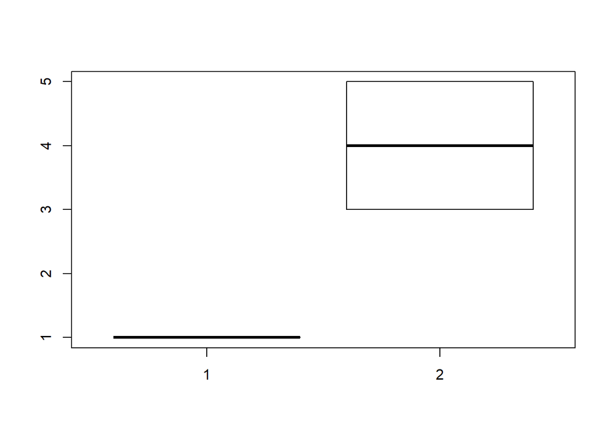

```r
boxplot(selected_no$Social.class.B1 , selected_yes$Social.class.B1 )
```

B1 Class represents people with high status, without being too wealthy. They’re the upper middle class of Canada. Areas with a higher proportion of B1 class have a higher chance of wanting a caravan. Let’s check the remaining classes

[Sign: Positive]

### SOCIAL CLASS B2

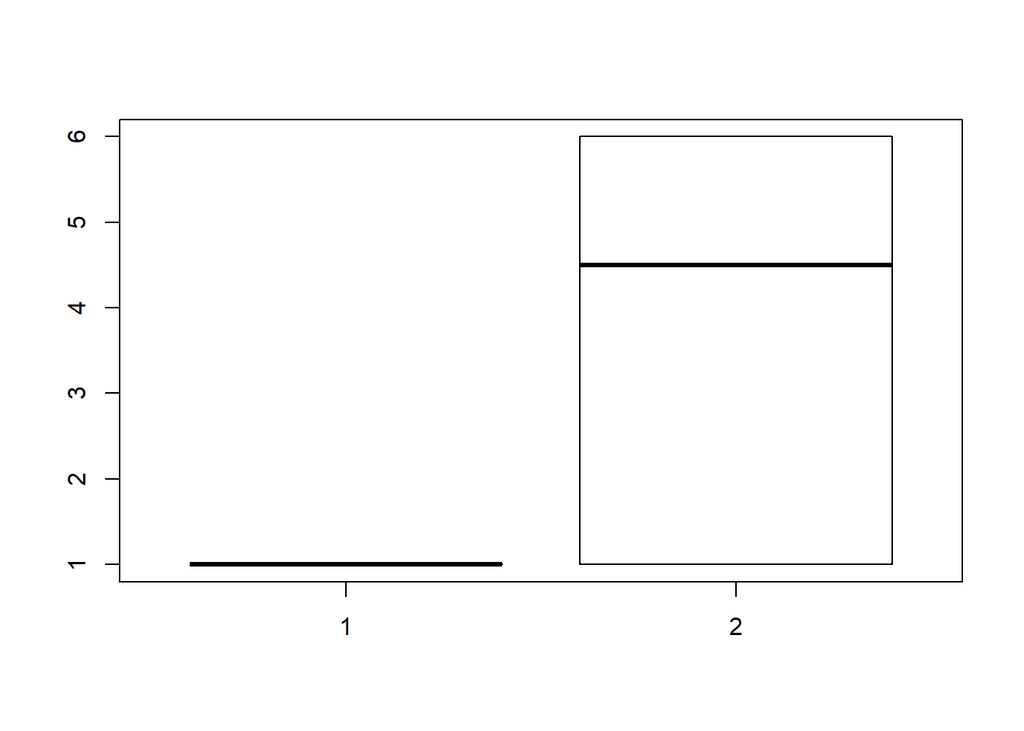

```r
boxplot(selected_no$Social.class.B2, selected_yes$Social.class.B2)
```

B2 class represents the middle class, middle management and above. Areas with a higher proportion of B2 want a caravan more often, but less than B1.

[Sign: Positive]

### SOCIAL CLASS C

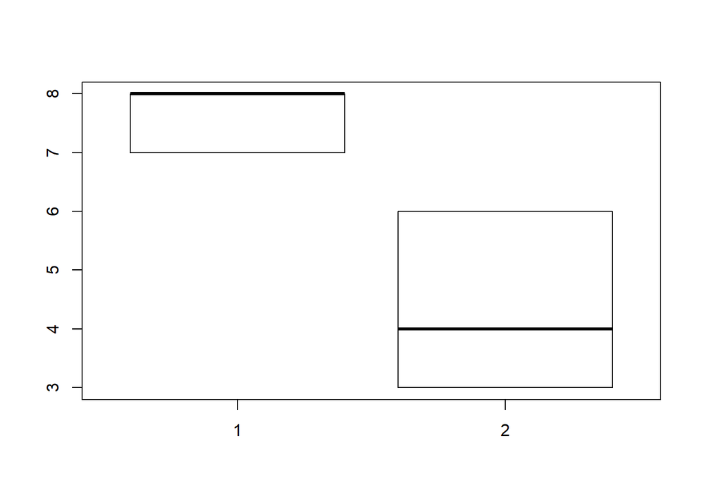

```r
boxplot(selected_no$Social.class.C , selected_yes$Social.class.C )
```

C represents the skilled labourers. Areas with a higher proportion of C do not want a caravan more often than not.

[Sign: Negative]

### SOCIAL CLASS D

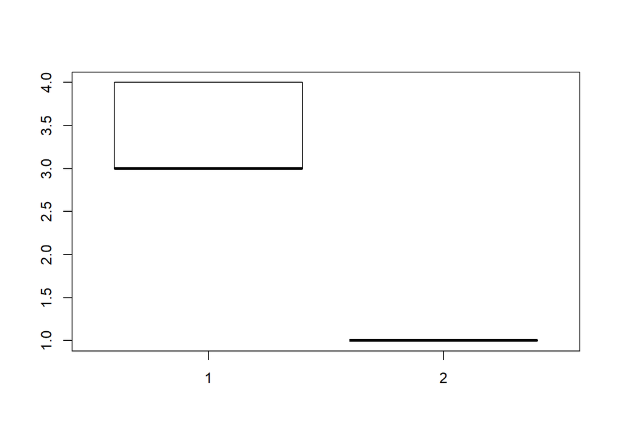

```r
boxplot(selected_no$Social.class.D , selected_yes$Social.class.D )
```

D represents the unskilled labourers. Areas with a higher proportion of D do not want a caravan even more so that C.

[Sign: Negative]

### SOCIAL CLASS CONCLUSION

There is a clear positive correlation between social class and the probability of wanting a caravan. It can be summed up like this: The higher the cash, the higher the desire of having a caravan.

## CAR OWNERSHIP

### ONE CAR

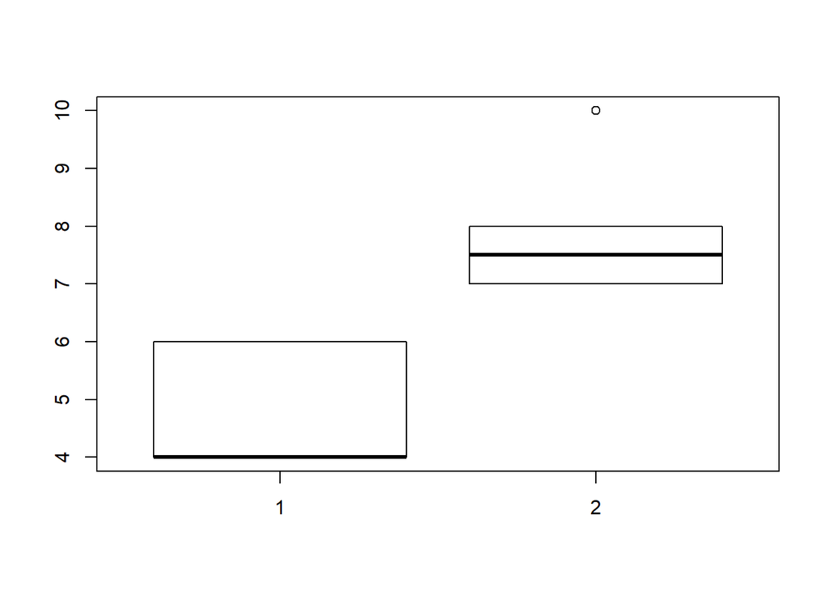

```r
boxplot(selected_no$X1.car , selected_yes$X1.car )
```

The areas with a higher proportion of families owning just one car have a higher chance of wanting a caravan. What about two cars?

[Sign: Positive]

### TWO CARS

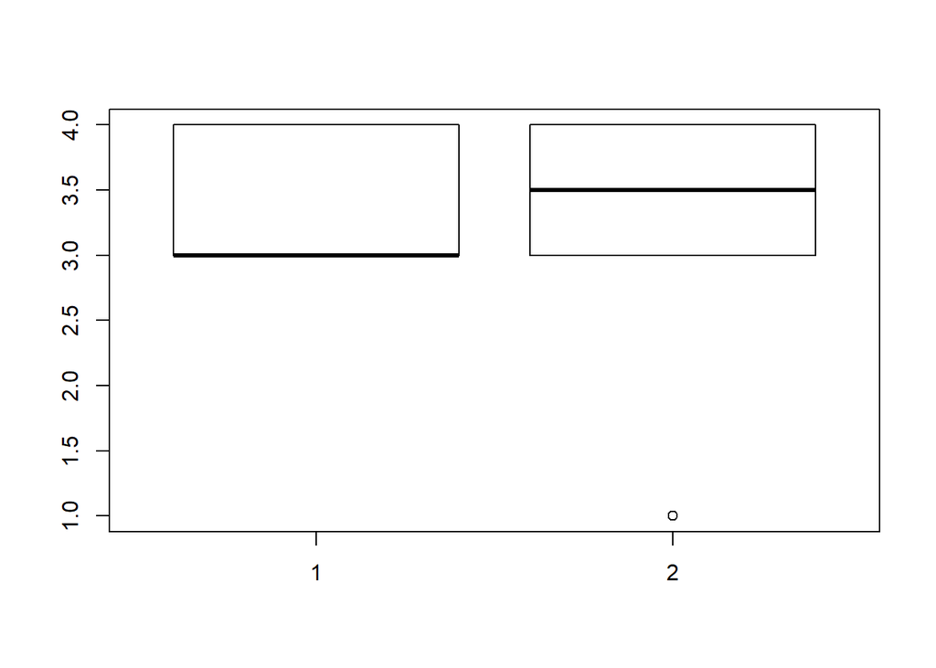

```r
boxplot(selected_no$X2.cars , selected_yes$X2.cars )
```

Two cars isn’t exactly significant. It is understandable because people owning two cars and more are of a higher status than the middle class, and we have already ascertained that it is mostly the middle class that wants a caravan. The wealthy are conflicted. It’s due to the fact that owning a caravan is a symbol of success, which makes people who are already successful to an extent (upper middle class) want it more. However, the rich already have everything they want. Why want a caravan when you can go parachute?

[Sign: Positive]

### NO CAR

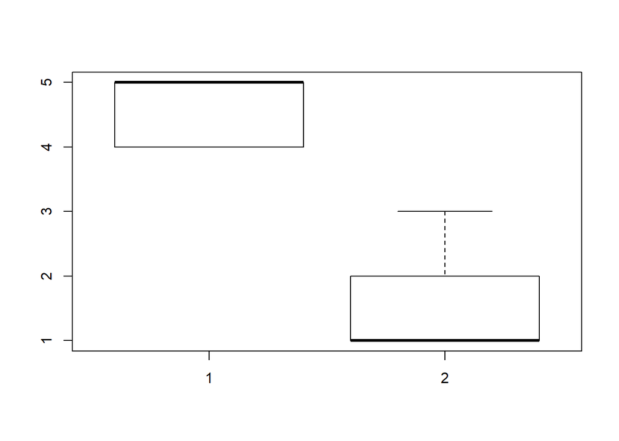

```r
boxplot(selected_no$No.car , selected_yes$No.car )
```

Areas with a higher proportion of people owning no cars have a higher chance of not wanting the caravan. It’s understandable: a caravan is a car-driven vehicle. Owning a caravan before the car is absurd.

[Sign: Negative]

### CARS CONCLUSION

The analysis of car ownership accross the regions shows a confirmation of earlier statements, that when it comes to caravans, the poor can’t have it, and the rich don’t want it.

## INCOME

### Less than 30000

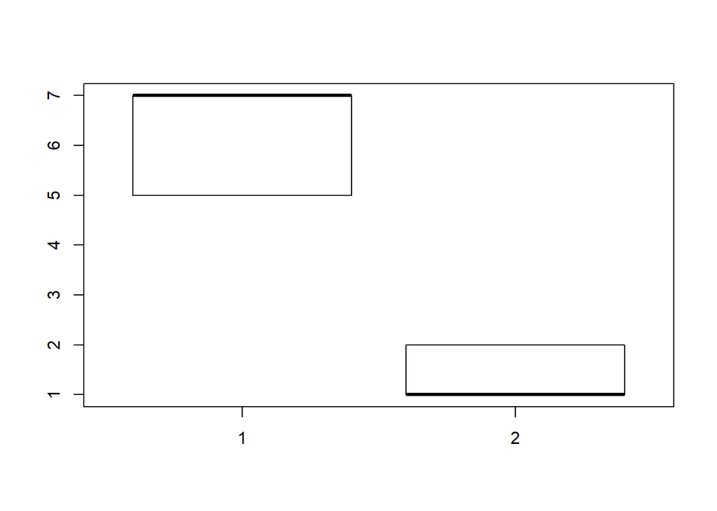

```r
boxplot(selected_no$Income...30.000 , selected_yes$Income...30.000 )
```

The areas with a high proporition of people earning less than 30000 generally do not want a caravan. It does confirm our previous statement.

[Sign: Negative]

### 30000 45000

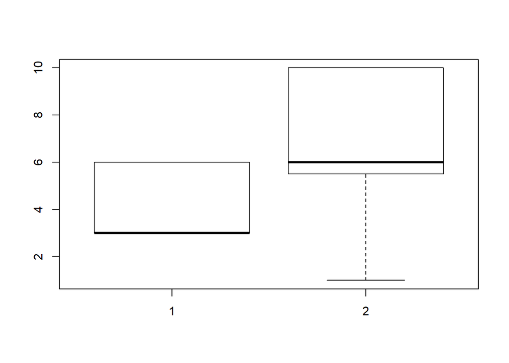

```r
boxplot(selected_no$Income.30.45.000 , selected_yes$Income.30.45.000 )
```

An area with a high proporition of people earning an income from 30000 to 45000 is slightly more enclined to say yes.

[Sign: Positive]

### 45000 75000

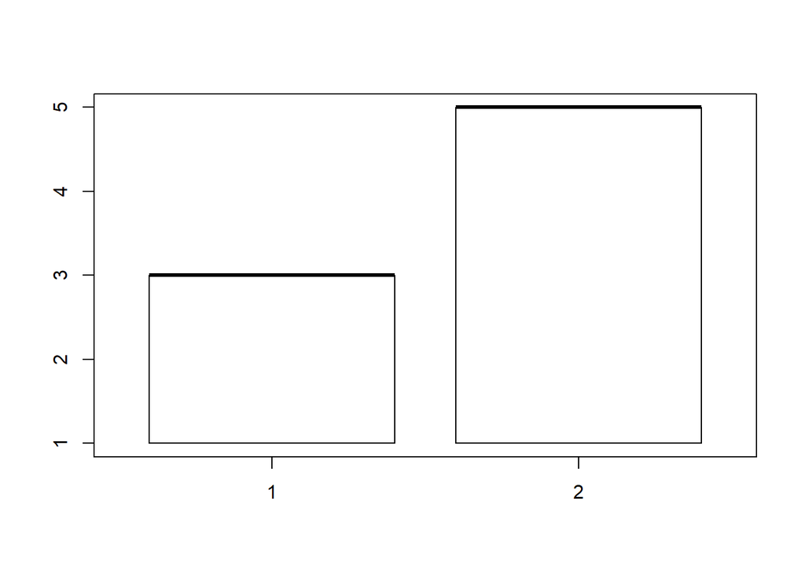

```r
boxplot(selected_no$Income.45.75.000 , selected_yes$Income.45.75.000 )
```

The population of an area with a high proportion of people earning an income between 45000 and 75000 has higher chance of wanting a caravan.

[Sign: Positive]

### Between 75000 and 122000

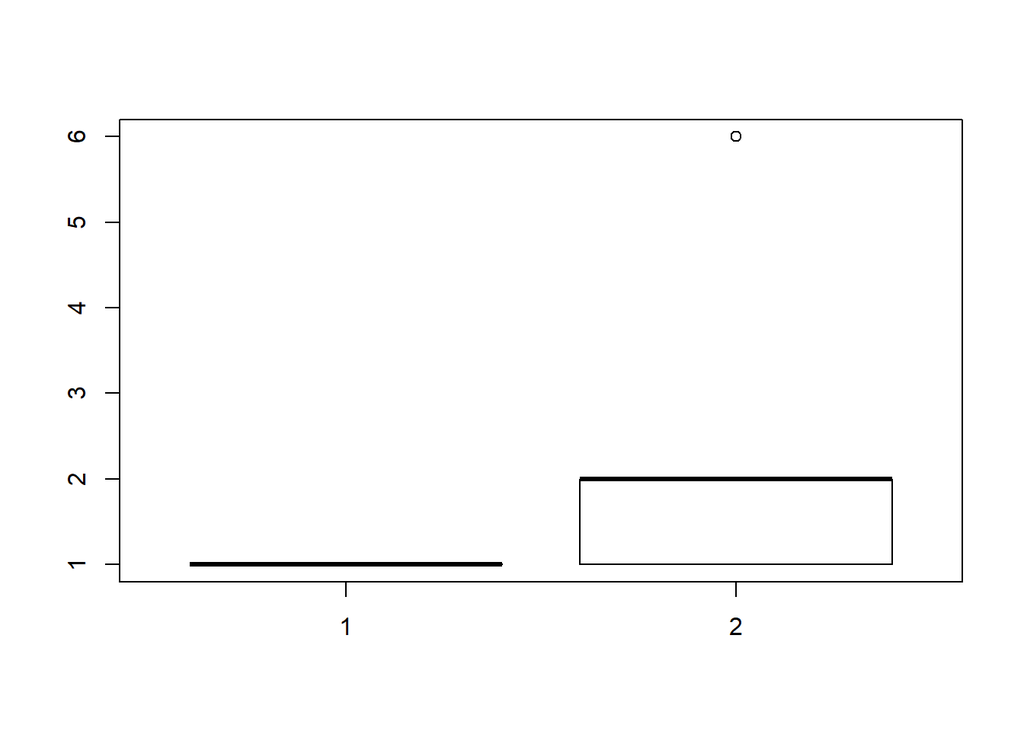

```r
boxplot(selected_no$Income.75.122.000 , selected_yes$Income.75.122.000 )
```

The trend remains, with areas having a higher proportion of an income between 75000 and 122000 having more chances of having a majority of people wanting a caravan.

[Sign: Positive]

### Average Income

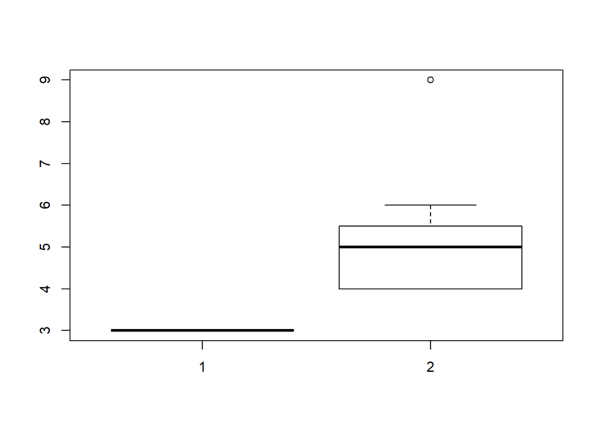

```r
boxplot(selected_no$Average.income , selected_yes$Average.income )
```

The average income for a family in Canada is around 76000 dollars. It does fit the trend with areas with a majority of families having the average income wanting the caravan more.

[Sign: Positive]

### Of Purchasing power class

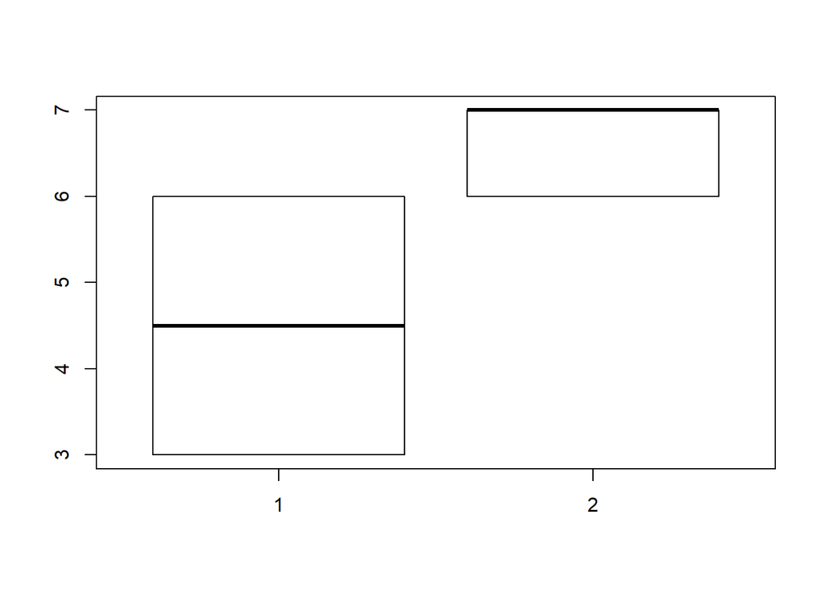

```r
boxplot(selected_no$Purchasing.power.class , selected_yes$Purchasing.power.class )
```

While we don’t know what a purchasing power class is, it does provide an obvious separation similar to the average income.

[Sign: Positive]

### More than 123000

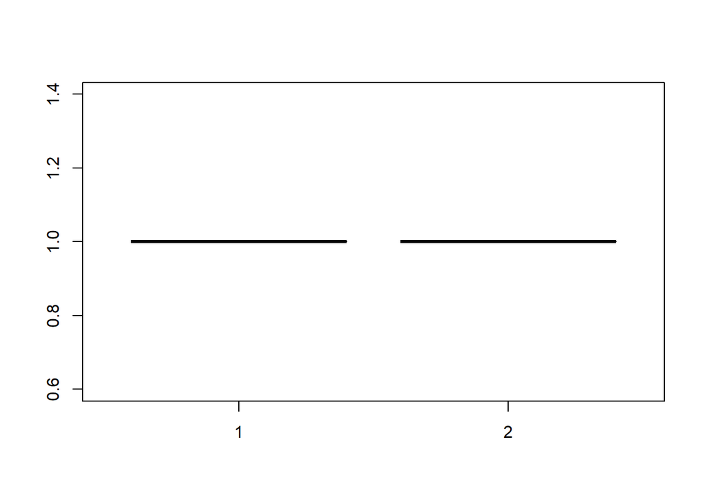

```r
boxplot(selected_no$Income..123.000 , selected_yes$Income..123.000 )
```

The trend is still verified: The wealthiest do not seem to care too much whether they want the caravan or not.

[Sign: None]

### INCOME CONCLUSION

It does seem very clearly now that our target is the upper middle class.

## Insurance ratios

A ratio = contribution to policy/number of policies

### Ratio Private third party insurance

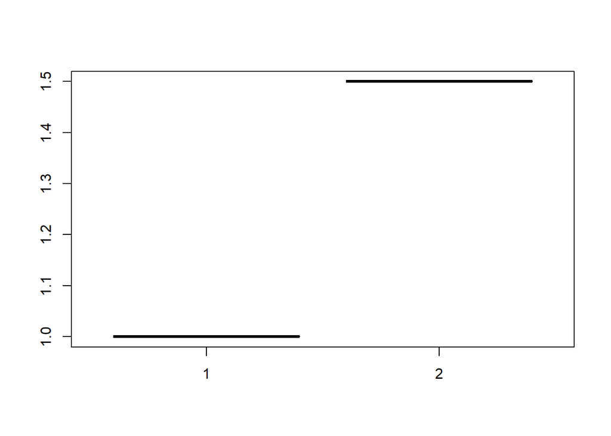

```r
boxplot(selected_no$RatioPrivateThirdParty , selected_yes$RatioPrivateThirdParty )
```

Areas with a higher ratio (thus a higher contribution) to third party insurance policies want the caravan more. It’s due to the fact that someone taking the time to choose between several insurance policies is someone that has the “insurance culture”, as in, the culture of wanting to put an insurance on various elements of life.

[Sign: Positive]

### Ratio Car insurance

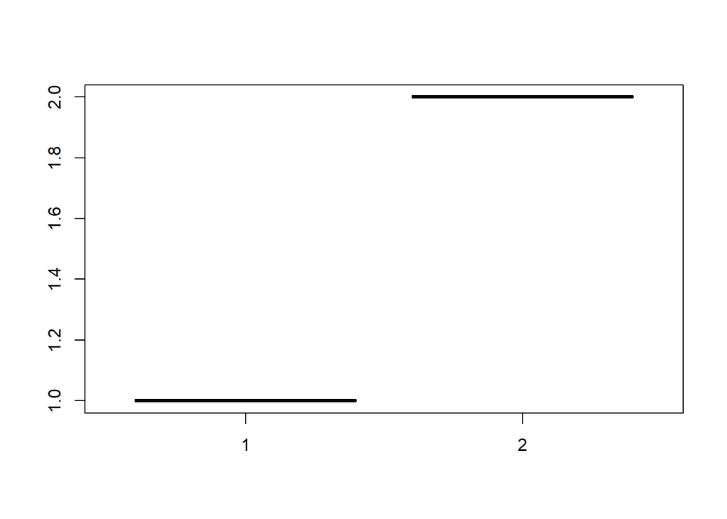

```r
boxplot(selected_no$RatioCar , selected_yes$RatioCar )
```

The constatation is similar, and slightly more interesting when it comes to cars: The ratio is much higher for the zones wanting a caravan

[Sign: Positive]

### Ratio Fire insurance

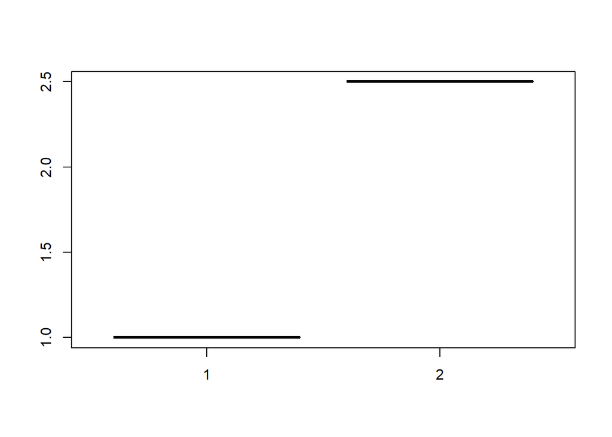

```r
boxplot(selected_no$RatioFire , selected_yes$RatioFire )
```

Same interpretation for the fire insurance ratio: The ratio is much higher for the zones wanting a caravan

[Sign: Positive]

### INSURANCE RATIOS CONCLUSION

The zones with a higher ratio (means a higher contribution or a lower number) are filled with people that have the “insurance culture”, as in, the culture of wanting to put an insurance on various elements of life. Thus they’re the people we target.

## SCORING GENERAL CONCLUSION

Basically our best target is a highly educated, catholic, stable, married, with children, upper middle class person with one car.

# ASSIGNING A SCORE TO EVERY CLIENT

Remember the gini score? Now we have both the gini score and the actual effect of every one of the most important variables. The plan is to get the gini score

```r
Imp_1=m3_1$importance
library(data.table)

Imp_1=as.data.frame(Imp_1)
setDT(Imp_1, keep.rownames = TRUE)[]
```

```
##                                             rn MeanDecreaseGini
##  1:                       Successful.hedonists        2.5024363
##  2:                             Driven.Growers        2.3364532
##  3:                             Average.Family        5.1596467
##  4:                                Living.well        4.4467550
##  5:                      Retired.and.Religeous        3.1000554
##  6:                      Family.with.grown.ups        5.5207316
##  7:                      Conservative.families        4.3700794
##  8:                                    Farmers        2.5618610
##  9:               High.Income..expensive.child        0.7957234
## 10:                        High.status.seniors        1.7341891
## 11:                      Middle.class.families        3.0307942
## 12:                  Modern..complete.families        2.4865195
## 13:                              Stable.family        2.4563207
## 14:                            Family.starters        1.5019416
```

[output cut: 61 more lines]

```r
Imp_1=Imp_1[order(Imp_1$MeanDecreaseGini, decreasing = T),]
```

then assign a sign to every one of the variables we tested, multiplying the gini score by the sign

```r
ScoreColumns=c("Catholic", "Protestant","Married","Other.relation", "Singles",
               "Household.without.children", "Household.with.children", "High.level.education",
               "Medium.level.education", "Lower.level.education", "High.status", "Farmer",
               "Middle.management","Skilled.labourers", "Unskilled.labourers", "Social.class.B1",
               "Social.class.B2", "Social.class.D","Social.class.C", "X1.car", "X2.cars", "No.car",
               "Income...30.000", "Income.75.122.000", "Average.income",
               "Purchasing.power.class", "RatioPrivateThirdParty", "RatioCar", "RatioFire")
ScoreSigns=c(1,-1,1,-1,-1,-1,1,1,1,-1,1,-1,1,-1,-1,1,1,-1,-1,1,1,-1,-1,1,1,1,1,1,1)
ScoreStepOne=data.frame(ScoreColumns, ScoreSigns)

names(ScoreStepOne)=c("rn", "Signs")
ScoreCoef=merge(Imp_1,ScoreStepOne)
ScoreCoef$ColumnScore=ScoreCoef$MeanDecreaseGini*ScoreCoef$Signs
ScoreCoef<-data.frame(ScoreCoef$rn, ScoreCoef$ColumnScore)
```

then multiply it by the actual values of the variables. There you go, we got ourselves a score per individual!

```r
selected<-selected[, colnames(selected) %in% c(ScoreColumns, "m3_1_fitForest_all", "target")]

for(b in ScoreColumns) selected[[b]] <- selected[[b]]*ScoreCoef[which(ScoreCoef$ScoreCoef.rn==b),2]

selected$Score=rowSums(selected)
testScore=data.frame(selected$Score, selected$target)
testScore[order(testScore$selected.Score,decreasing=T),]
```

```
##    selected.Score selected.target
## 22     2624.30958               1
## 24     2624.30948               1
## 13     1939.99564               1
## 15     1939.99564               1
## 16     1939.99564               1
## 14     1938.99564               0
## 17     1871.75645               1
## 19     1871.75645               1
## 20     1871.75645               1
## 18     1870.75645               0
## 21     1870.75645               0
## 23     1648.63352               1
## 5        58.95485               0
## 4        58.95455               0
## 1        58.95440               0
## 2        58.95440               0
## 3        58.95440               0
## 10     -239.89523               0
## 11     -239.89523               0
## 12     -239.89523               0
## 7      -239.89528               0
## 8      -239.89528               0
## 9      -239.89528               0
## 6      -308.40779               0
```

Now, notice how the score fits almost perfectly our target. The higher the score, the higher the chance of having a one. Now what does it mean to have a high score? It means that you have the profile of someone that would want a caravan. The presence of these 0 in the list of high scores shows an interesting conclusion: These are the areas we should target as a company, as they have the profile but they don’t want a caravan.

What if we test this scoring method on the main dataset?

```r
Dummies_proba_all<-Dummies_proba_all[, colnames(Dummies_proba_all) %in% c(ScoreColumns, "m3_1_fitForest_all", "target")]

for(b in colnames(Dummies_proba_all)) Dummies_proba_all[[b]] <- as.numeric(Dummies_proba_all[[b]])
Dummies_proba_all$target<-Dummies_proba_all$target-1
for(b in ScoreColumns) Dummies_proba_all[[b]] <- Dummies_proba_all[[b]]*ScoreCoef[which(ScoreCoef$ScoreCoef.rn==b),2]

Dummies_proba_all$Score=rowSums(Dummies_proba_all)
testScore=data.frame(Dummies_proba_all$Score, Dummies_proba_all$target)
head(testScore[order(testScore$Dummies_proba_all.Score,decreasing=T),],50)
```

```
##      Dummies_proba_all.Score Dummies_proba_all.target
## 8239                2709.408                        1
## 7935                2708.408                        0
## 3323                2657.290                        0
## 4882                2624.310                        1
## 3742                2624.309                        1
## 5171                2624.309                        1
## 8804                2582.346                        1
## 3052                2562.313                        0
## 483                 2548.450                        0
## 4103                2539.363                        0
## 9177                2517.934                        0
## 3099                2505.665                        0
## 1782                2492.504                        0
## 390                 2488.219                        0
```

[output cut: 36 more lines]

As you can see here, there are a lot of clients that have the profile we seek. These are our targets. The company didn’t provide us with any way of identifying the areas, but if we did have that, we’d make the marketing department very happy.